# Презентация по лабораторной работе №11

Дисциплина: операционные системы

Лобанова П. И.

Российский университет дружбы народов, Москва, Россия

21.04.2023

# Информация

## Докладчик

- Лобанова Полина Иннокентьевна
- учащаяся факультета физико-математических и естественных наук
- учащаяся направления “Компьютерные и информационные науки”
- Российский университет дружбы народов
- polla-2004@mail.ru

# Цель

Изучить основы программирования в оболочке ОС UNIX. Научится писать более сложные командные файлы с использованием логических управляющих конструкций и циклов.

# Ход работы

## Первое задание

Используя команды getopts grep, написать командный файл, который анализирует командную строку с ключами: -i, -o, -p, -C, -n, а затем ищет в указанном файле нужные строки, определяемые ключом -p.

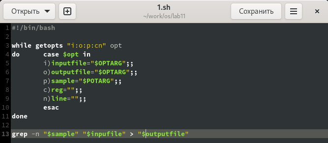

*Текст программы.*

## Второе задание

Написать на языке Си программу, которая вводит число и определяет, является ли оно больше нуля, меньше нуля или равно нулю. Затем программа завершается с помощью функции exit(n), передавая информацию в о коде завершения в оболочку. Командный файл должен вызывать эту программу и, проанализировав с помощью команды $?, выдать сообщение о том, какое число было введено.

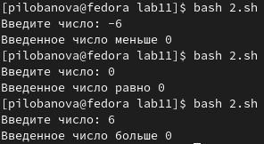

*Результат программы.*

## Третье задание

Написать командный файл, создающий указанное число файлов, пронумерованных последовательно от 1 до N (например 1.tmp, 2.tmp, 3.tmp,4.tmp и т.д.). Число файлов, которые необходимо создать, передаётся в аргументы командной строки. Этот же командный файл должен уметь удалять все созданные им файлы.

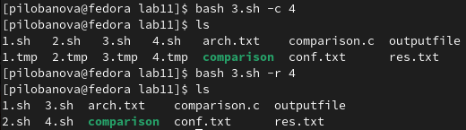

*Результат программы.*

## Четвертое задание

Написать командный файл, который с помощью команды tar запаковывает в архив все файлы в указанной директории. Модифицировать его так, чтобы запаковывались только те файлы, которые были изменены менее недели тому назад.

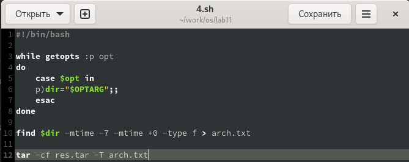

*Текст программы.*

# Контрольные вопросы

1. Каково предназначение команды getopts?
2. Какое отношение метасимволы имеют к генерации имён файлов?
3. Какие операторы управления действиями вы знаете?
4. Какие операторы используются для прерывания цикла?
5. Для чего нужны команды false и true?
6. Что означает строка if test -f man*s*/i.$s, встреченная в командном файле?
7. Объясните различия между конструкциями while и until.

# Вывод

Я изучила основы программирования в оболочке ОС UNIX и научилась писать более сложные командные файлы с использованием логических управляющих конструкций и циклов.